# ICBC Descriptive Memo

Crashes involving cyclists, 2014-2017

Jaimy Fischer

February 19, 2019

```r
library(leaflet)
library(tidyr)
library(rgdal)
library(htmlwidgets)
library(leaflet)
library(tidyverse)
library(sp)
library(htmlwidgets)
library(readr)
library(knitr)

CRD <- read_csv("CRD.csv")
CRD <- CRD %>%
  mutate(latitude = as.numeric(Latitude),
         longitude = as.numeric(Longitude),
         CITY_GROUPING = "CRD")

#filter out non-geolocated incidents for mapping
CRDgeocoded <- CRD %>%
  filter(!is.na(latitude)) %>%
  select(Year, Month, Day, `City Name`, `Road Location`, latitude, longitude,
         CRASHES)

  #rename columns
CRDgeocoded <-  rename(CRDgeocoded,
             year = Year,
             month = Month,
             day = Day,
             muni = `City Name`,
             rd = `Road Location`,
             latitude = latitude,
             longitude = longitude,
             crashes = CRASHES) %>%
  mutate(year = as.factor(year))

#create separate layers for each year
Y2014 <- CRDgeocoded %>%
  filter(year == 2014)

Y2015 <- CRDgeocoded %>%
  filter(year == 2015)

Y2016 <- CRDgeocoded %>%
  filter(year == 2016)

Y2017 <- CRDgeocoded %>%
  filter(year == 2017)

#Kelowna
KEL <- read_csv("KEL.csv")
KEL <- KEL %>%
    mutate(latitude = as.numeric(Latitude),
           longitude = as.numeric(Longitude),
           CITY_GROUPING = "KELOWNA")

  #filter out non-geolocated incidents for mapping
Kgeocoded <- KEL %>%
    filter(!is.na(latitude)) %>%
    select(Year, Month, Day, `City Name`, `Road Location`, latitude, longitude,
           CRASHES)

  #rename columns
  Kgeocoded <-  rename(Kgeocoded,
                      year = Year,
                      month = Month,
                      day = Day,
                      muni = `City Name`,
                      rd = `Road Location`,
                      latitude = latitude,
                      longitude = longitude,
                      crashes = CRASHES) %>%
    mutate(year = as.factor(year))

  #create separate layers for each year
  K2014 <- Kgeocoded %>%
    filter(year == 2014)

  K2015 <- Kgeocoded %>%
    filter(year == 2015)

  K2016 <- Kgeocoded %>%
    filter(year == 2016)

  K2017 <- Kgeocoded %>%
    filter(year == 2017)

#Metro Van
METRO <- read_csv("METRO.csv")
METRO <- METRO %>%
    mutate(latitude = as.numeric(Latitude),
           longitude = as.numeric(Longitude),
           CITY_GROUPING = "METRO VANCOUVER")

  #filter out non-geolocated incidents for mapping
Mgeocoded <- METRO %>%
    filter(!is.na(latitude)) %>%
    select(Year, Month, Day, `City Name`, `Road Location`, latitude, longitude,
           CRASHES)

  #rename columns
  Mgeocoded <-  rename(Mgeocoded,
                      year = Year,
                      month = Month,
                      day = Day,
                      muni = `City Name`,
                      rd = `Road Location`,
                      latitude = latitude,
                      longitude = longitude,
                      crashes = CRASHES) %>%
    mutate(year = as.factor(year))

  #create separate layers for each year
  M2014 <- Mgeocoded %>%
    filter(year == 2014)

  M2015 <- Mgeocoded %>%
    filter(year == 2015)

  M2016 <- Mgeocoded %>%
    filter(year == 2016)

  M2017 <- Mgeocoded %>%
    filter(year == 2017)

  ###historic data
hist09 <- read_csv("ICBC 2009_2013/2009.csv")
hist09 <- hist09 %>%
  select(CRASHES, DATE, YEAR, MONTH, `DAY OF WEEK`, TIME, ROAD_LOCATION,
         SEVERITY, CITY, CITY_GROUPING, GEOCODE_LATITUDE, GEOCODE_LONGITUDE) %>%
  mutate(latitude = as.numeric(GEOCODE_LATITUDE),
         longitude = as.numeric(GEOCODE_LONGITUDE))

hist10 <- read_csv("ICBC 2009_2013/2010.csv")
hist10 <- hist10 %>%
  select(CRASHES, DATE, YEAR, MONTH, `DAY OF WEEK`, TIME, ROAD_LOCATION,
         SEVERITY, CITY, CITY_GROUPING, GEOCODE_LATITUDE, GEOCODE_LONGITUDE) %>%
  mutate(latitude = as.numeric(GEOCODE_LATITUDE),
         longitude = as.numeric(GEOCODE_LONGITUDE))

hist11 <- read_csv("ICBC 2009_2013/2011.csv")
hist11 <- hist11 %>%
  select(CRASHES, DATE, YEAR, MONTH, `DAY OF WEEK`, TIME, ROAD_LOCATION,
         SEVERITY, CITY, CITY_GROUPING, GEOCODE_LATITUDE, GEOCODE_LONGITUDE) %>%
  mutate(latitude = as.numeric(GEOCODE_LATITUDE),
         longitude = as.numeric(GEOCODE_LONGITUDE))

hist12 <- read_csv("ICBC 2009_2013/2012.csv")
hist12 <- hist12 %>%
  select(CRASHES, DATE, YEAR, MONTH, `DAY OF WEEK`, TIME, ROAD_LOCATION,
         SEVERITY, CITY, CITY_GROUPING, GEOCODE_LATITUDE, GEOCODE_LONGITUDE) %>%
  mutate(latitude = as.numeric(GEOCODE_LATITUDE),
         longitude = as.numeric(GEOCODE_LONGITUDE))

hist13 <- read_csv("ICBC 2009_2013/2013.csv")
hist13 <- hist13 %>%
  select(CRASHES, DATE, YEAR, MONTH, `DAY OF WEEK`, TIME, ROAD_LOCATION,
         SEVERITY, CITY, CITY_GROUPING, GEOCODE_LATITUDE, GEOCODE_LONGITUDE) %>%
  mutate(latitude = as.numeric(GEOCODE_LATITUDE),
         longitude = as.numeric(GEOCODE_LONGITUDE))

historicICBC <- rbind(hist09, hist10, hist11, hist12, hist13)

CRD <- CRD %>%
  mutate(geocoded = if_else(!is.na(latitude), "Y", "N")) %>%
  mutate(month_short = substr(Month, 1, 3))

CRDHistoric <- historicICBC %>%
  filter(CITY_GROUPING == "CRD") %>%
  mutate(geocoded = if_else(!is.na(latitude), "Y", "N"))

KEL <- KEL %>%
  mutate(geocoded = if_else(!is.na(latitude), "Y", "N")) %>%
  mutate(month_short = substr(Month, 1, 3))

METRO <- METRO %>%
  mutate(geocoded = if_else(!is.na(latitude), "Y", "N")) %>%
  mutate(month_short = substr(Month, 1, 3))

METROHistoric <- historicICBC %>%
  filter(CITY_GROUPING == "METRO VANCOUVER") %>%
  mutate(geocoded = if_else(!is.na(latitude), "Y", "N"))
```

```r
historicReports <- historicICBC %>%
  filter(CITY_GROUPING != "OTHER") %>%
  group_by(CITY_GROUPING, YEAR) %>%
  summarize(reports = sum(CRASHES)) %>%
  rename(region = CITY_GROUPING,
         year = YEAR)

currentReports <- rbind(CRD, METRO, KEL) %>%
  group_by(CITY_GROUPING, Year) %>%
  summarize(reports = sum(CRASHES)) %>%
  rename(region = CITY_GROUPING,
         year = Year)

allReports <- rbind(historicReports, currentReports) %>%
arrange(region, year)

pops <- data.frame(population = c(338531,341521,    342684, 348014, 353317, 359922, 368834, 376309, 381121, 125233, 128769, 131654, 133644, 2276716, 2322374,   2345186, 2388425,   2423845,    2462471,    2496804, 2544220, 2579442), year = c(2009, 2010, 2011, 2012, 2013, 2014, 2015, 2016, 2017, 2014, 2015, 2016, 2017, 2009, 2010, 2011, 2012, 2013, 2014, 2015, 2016, 2017), region = c("CRD", "CRD", "CRD", "CRD", "CRD", "CRD", "CRD", "CRD", "CRD", "KELOWNA", "KELOWNA", "KELOWNA", "KELOWNA", "METRO VANCOUVER", "METRO VANCOUVER", "METRO VANCOUVER", "METRO VANCOUVER", "METRO VANCOUVER", "METRO VANCOUVER", "METRO VANCOUVER", "METRO VANCOUVER", "METRO VANCOUVER"))

allReports <- left_join(allReports, pops, by = c("year", "region"))
allReports <- allReports %>%
  mutate(relative = (reports/population) * 100)

allReports$year <- as.factor(allReports$year)
allReports$region <- as.factor(allReports$region)
```

# Introduction

This document describes the data quality of the latest release (2014-2017) of ICBC reports involving cyclists for Metro Vancouver, the Capital Regional District (CRD) and Kelowna. MW shared the details of the report with ICBC representative Tom Webster; questions and responses are detailed at the bottom of this introduction.

Generally for this period, in the CRD and Metro Vancouver, the number of ICBC reports increased between 2014 and 2015. The largest increase was in Vancouver, with the number of reports rising from 1253 crashes in 2014 to 1446 in 2015; in the CRD the number of reports rose from 281 in 2014 to 320 in 2015. In Metro Vancouver the number of reports declines after 2015, with 1378 reports in 2016 and 1268 reports in 2017. In the CRD the number of reports in 2016 and 2017 was similar to 2015 (315 and 316 respectively). In Kelowna the number of reports was consistent across years (min = 98 reports (2017) max = 110 reports (2016)). When reports are normalized to the regional populations, trends hold. The number of reports were not checked against mode share, but could be related.

**Geocoded reports** Overall, 2017 had the highest proprtion of spatially complete reports, and 2014 had the least.

The CRD had the highest proportions of non-geocoded reports, consistent across all years. Historically, less than 2% of reports were non-geolocated in both the CRD and Metro Vancovuer (no historical data for Kelowna). In the CRD between 2014-2017 the proportion of spatially incompelete reports was 31% in 2014, 23% in 2015, 27% in 2016 and 19% in 2017.

**Seasonal reporting**  
Historically, peak reporting for these regions occurs between May-Oct, with the number of reports highest between June and August and declining thereafter.

CRD: Patterns of seasonal reporting varied. Peak reporting occurred in the month June in 2014 and 2015, July in 2016, and August in 2017.The peak in 2015 was greater than in other years, possibly reflecting the increase in reports for that year. In 2014 the data show a seasonal peak in June, and then a decline through July and August. The greatest peak during 2014 is in December–**this trend is unusual**. As reference, the peak number of reports in June 2014 was 30, and the number of reports in December was 35.

Metro Vancouver: Patterns reflecting seasonal peaks were relatively consistent when compared to the CRD, with no apparent gaps. The notable inconsistency is the seasonal peak in June in 2015: while the seasonal peaks in other years occurs between July-August. The peak in 2015 was also greater than in other years, with 198 reports; in comparison, in June, 2014 had 136 reports, 2016 had 154 and 2017 had 147.

Kelowna: The most normal years with respect to seasonal peaks were 2014 and 2017, with trends showing a bell curve peaking around the summer season. In 2015 there was a small peak in May, a dip in July and a peak in September;2016 also peaked in September. It’s possible that the different trends (later peak reports) could be related to ridership and weather, as temperatures in this regiona are typically high in July (30+). In 2015, for example, some days in July had a maximum temperature of almost 40c; we see a dip in reports for this month/year that could be consistent with the weather trend.

**Intersection geocoding**  
The proportion of reports geolocated to intersections was consistent across all three regions between 2014 and 2017, with proportions between 84-90%. Overall, Metro Vancouver had the highest average proportion of reports geolocated to intersections (90%) and the CRD had the least (between 87%). Kelowna ranged from 84-91%, and the average was 88%.

In addition to reports located at either an intersection or along a city block, some reports lacked the road location; these reports had geographic coordinates assigned, but the road location was “unknown”. This data gap was most obvious in 2016 and 2017, with the CRD and Metro Vancouver ranging from 5-8% coded as unknown, and Kelowna ranging from 5-13%.

## Data questions asked of ICBC data team

In general, data quality caveats indicated that trends in historical data (pre-2014) should not be compared to trends post-2014, and that there may be some spatial bias in the data due to geocoding methods. Spatial accuracy for incidents reported before April 2017 may be diminshed for lack of a Digital Road Atlas system update on the ICBC side (see below). It is unclear if spatial bias is concentrated in any particular area or distributed evenly throughout the study areas. Further investigation might help answer this question.

**Q1. Total crashes: We noted that in the 2014-2017 data, in the CRD and Metro Vancouver, the number of reports noticeably increased between 2014 and 2015. We wonder about ideas on this? Of course the number of reports could be related to mode share changes - we haven’t the data to check this yet.**

*A: There were major changes in our claims and reporting systems implemented between 2013 and 2015 and that may have affected the numbers as we transitioned between computer systems.*

**Q2. Geocoding reports: We noticed that the proportion of locations that is geocoded is lower in this dataset as compared to past ICBC datasets (e.g., 2009-2013), and also that it varied from city to city. Can you let us know about why some incidents lack geocoding, and why patterns may vary in space and time?**

*A: Geocoded locations for crashes reported before April 2017 have not been updated with the most recent Digital Road Atlas. We are planning on addressing this issue later in the year and apparently it requires complex programming work to accomplish so won’t be a quick fix.*

**Q3. Intersection geocoding: I just wanted to check in about the process for ‘snapping’ crashes to intersections (or mid-block) to better understand spatial accuracy. We also wonder if in-house processes have changed from pre-2014 to this dataset, as we see different proportions at intersections. See in notes also questions around ‘unknown’ locations.**

*A: Geocoded locations for crashes reported before April 2017 have not been updated with the most recent Digital Road Atlas. We are planning on addressing this issue later in the year and apparently it requires complex programming work to accomplish so won’t be a quick fix (same as Q2)*

See below for tables and figures

## Yearly ICBC reports and reports as a proporiton of the population

### Number of reports

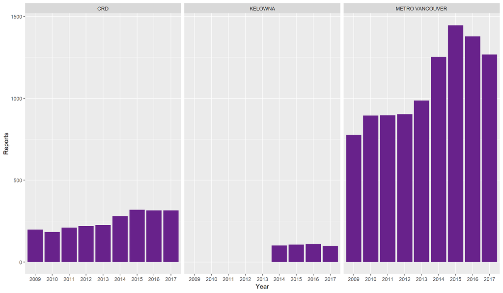

```r
allReports$year <- as.factor(allReports$year)
allReports$region <- as.factor(allReports$region)

allReports %>%  ggplot(aes(x = year, y = reports)) +
      geom_bar(stat = "identity", fill = "darkorchid4") +
      facet_wrap( ~ region, ncol = 3) +
  xlab("Year") +
  ylab("Reports")
```

```r
kable(allReports)
```

| region | year | reports | population | relative |
| --- | --- | --- | --- | --- |
| CRD | 2009 | 199 | 338531 | 0.0587834 |
| CRD | 2010 | 184 | 341521 | 0.0538766 |
| CRD | 2011 | 210 | 342684 | 0.0612809 |
| CRD | 2012 | 220 | 348014 | 0.0632158 |
| CRD | 2013 | 227 | 353317 | 0.0642483 |
| CRD | 2014 | 281 | 359922 | 0.0780725 |
| CRD | 2015 | 320 | 368834 | 0.0867599 |
| CRD | 2016 | 315 | 376309 | 0.0837078 |
| CRD | 2017 | 316 | 381121 | 0.0829133 |
| KELOWNA | 2014 | 101 | 125233 | 0.0806497 |
| KELOWNA | 2015 | 106 | 128769 | 0.0823179 |
| KELOWNA | 2016 | 110 | 131654 | 0.0835523 |
| KELOWNA | 2017 | 98 | 133644 | 0.0733291 |
| METRO VANCOUVER | 2009 | 776 | 2276716 | 0.0340842 |
| METRO VANCOUVER | 2010 | 895 | 2322374 | 0.0385382 |
| METRO VANCOUVER | 2011 | 896 | 2345186 | 0.0382059 |
| METRO VANCOUVER | 2012 | 903 | 2388425 | 0.0378073 |
| METRO VANCOUVER | 2013 | 987 | 2423845 | 0.0407204 |
| METRO VANCOUVER | 2014 | 1253 | 2462471 | 0.0508838 |
| METRO VANCOUVER | 2015 | 1446 | 2496804 | 0.0579140 |
| METRO VANCOUVER | 2016 | 1378 | 2544220 | 0.0541620 |
| METRO VANCOUVER | 2017 | 1268 | 2579442 | 0.0491579 |

### Proportion

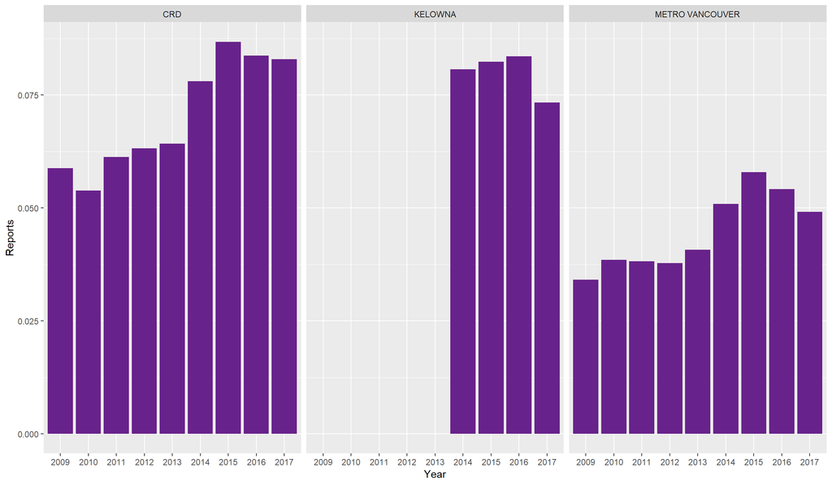

```r
allReports$year <- as.factor(allReports$year)
allReports$region <- as.factor(allReports$region)

allReports %>%  ggplot(aes(x = year, y = relative)) +
      geom_bar(stat = "identity", fill = "darkorchid4") +
      facet_wrap( ~ region, ncol = 3) +
  xlab("Year") +
  ylab("Reports")
```

## Number and proportion of geocoded vs non-geocoded crashes

### CRD

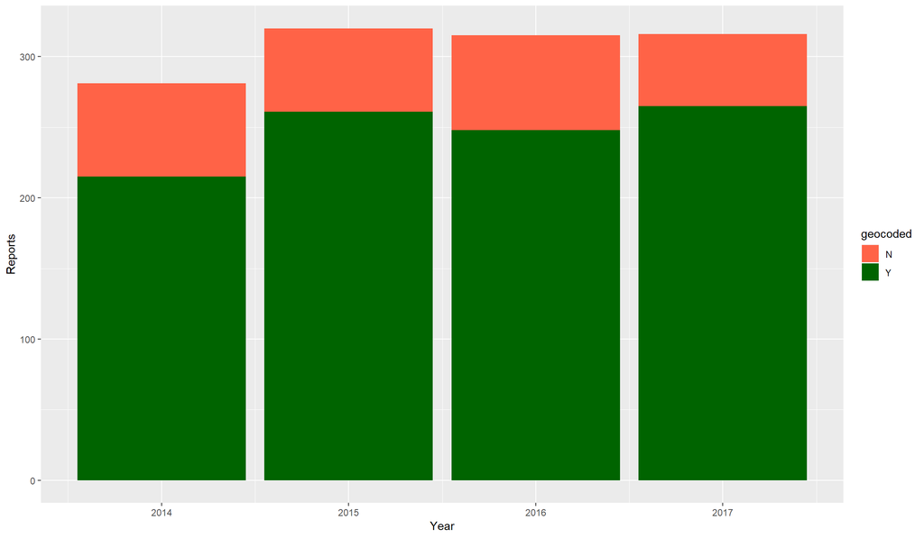

```r
CRDsummary <- CRD %>%
  select(Month, Year, CRASHES, geocoded) %>%
  group_by(Year, geocoded) %>%
  summarize(crashes = sum(CRASHES)) %>%
  mutate(freq = crashes/lead(crashes) * 100)


CRDsummary %>%
  ggplot(aes(x = Year, y = crashes, fill = geocoded)) +
  geom_bar(stat = "identity") +
  xlab("Year") +
  ylab("Reports") +
  scale_fill_manual(values = c("tomato", "darkgreen"))
```

```r
kable(CRDsummary)
```

| Year | geocoded | crashes | freq |
| --- | --- | --- | --- |
| 2014 | N | 66 | 30.69767 |
| 2014 | Y | 215 | NA |
| 2015 | N | 59 | 22.60536 |
| 2015 | Y | 261 | NA |
| 2016 | N | 67 | 27.01613 |
| 2016 | Y | 248 | NA |
| 2017 | N | 51 | 19.24528 |
| 2017 | Y | 265 | NA |

### Historic CRD

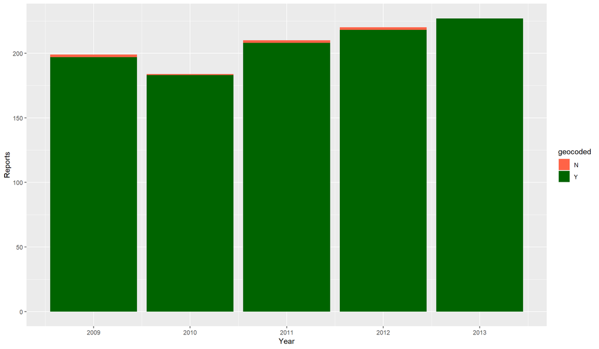

```r
histSummary <- CRDHistoric %>%
  select(MONTH, YEAR, CRASHES, geocoded) %>%
  group_by(YEAR, geocoded) %>%
  summarize(crashes = sum(CRASHES)) %>%
  mutate(freq = crashes/lead(crashes) * 100)

histSummary  %>%
  ggplot(aes(x = YEAR, y = crashes, fill = geocoded)) +
  geom_bar(stat = "identity") +
  xlab("Year") +
  ylab("Reports") +
  scale_fill_manual(values = c("tomato", "darkgreen"))
```

```r
kable(histSummary)
```

| YEAR | geocoded | crashes | freq |
| --- | --- | --- | --- |
| 2009 | N | 2 | 1.0152284 |
| 2009 | Y | 197 | NA |
| 2010 | N | 1 | 0.5464481 |
| 2010 | Y | 183 | NA |
| 2011 | N | 2 | 0.9615385 |
| 2011 | Y | 208 | NA |
| 2012 | N | 2 | 0.9174312 |
| 2012 | Y | 218 | NA |
| 2013 | Y | 227 | NA |

### Kelowna

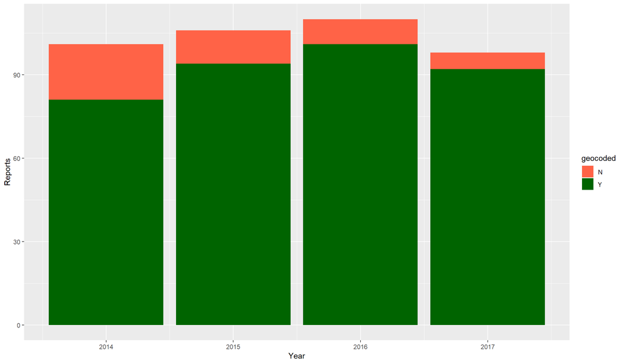

```r
KELsummary <- KEL %>%
  select(Month, Year, CRASHES, geocoded) %>%
  group_by(Year, geocoded) %>%
  summarize(crashes = sum(CRASHES)) %>%
  mutate(freq = crashes/lead(crashes) * 100)


KELsummary %>%
  ggplot(aes(x = Year, y = crashes, fill = geocoded)) +
  geom_bar(stat = "identity") +
  xlab("Year") +
  ylab("Reports") +
  scale_fill_manual(values = c("tomato", "darkgreen"))
```

```r
kable(KELsummary)
```

| Year | geocoded | crashes | freq |
| --- | --- | --- | --- |
| 2014 | N | 20 | 24.691358 |
| 2014 | Y | 81 | NA |
| 2015 | N | 12 | 12.765957 |
| 2015 | Y | 94 | NA |
| 2016 | N | 9 | 8.910891 |
| 2016 | Y | 101 | NA |
| 2017 | N | 6 | 6.521739 |
| 2017 | Y | 92 | NA |

### Metro Vancouver

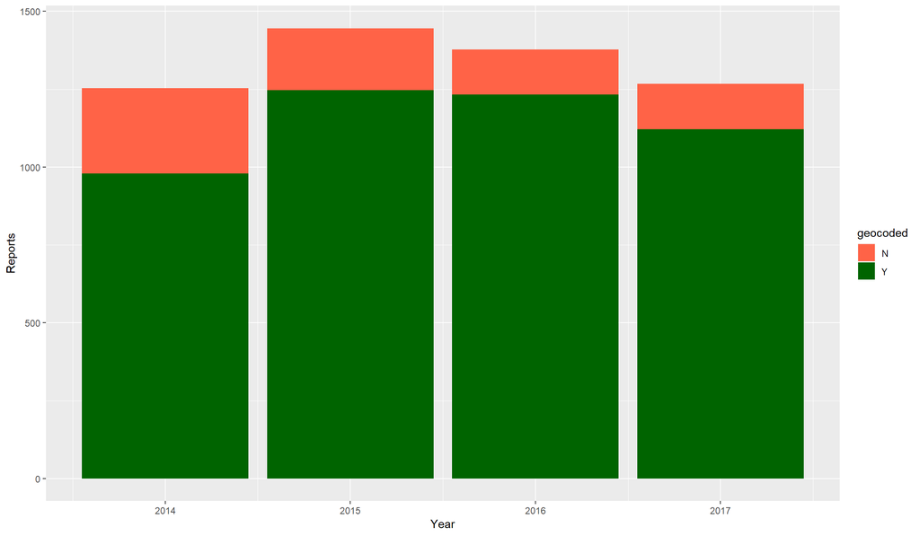

```r
METsummary <- METRO %>%
  select(Month, Year, CRASHES, geocoded) %>%
  group_by(Year, geocoded) %>%
  summarize(crashes = sum(CRASHES)) %>%
  mutate(freq = crashes/lead(crashes) * 100)


METsummary %>%
  ggplot(aes(x = Year, y = crashes, fill = geocoded)) +
  geom_bar(stat = "identity") +
  xlab("Year") +
  ylab("Reports") +
  scale_fill_manual(values = c("tomato", "darkgreen"))
```

```r
kable(METsummary)
```

| Year | geocoded | crashes | freq |
| --- | --- | --- | --- |
| 2014 | N | 274 | 27.98774 |
| 2014 | Y | 979 | NA |
| 2015 | N | 199 | 15.95830 |
| 2015 | Y | 1247 | NA |
| 2016 | N | 145 | 11.75994 |
| 2016 | Y | 1233 | NA |
| 2017 | N | 146 | 13.01248 |
| 2017 | Y | 1122 | NA |

### Historic Metro Vancouver

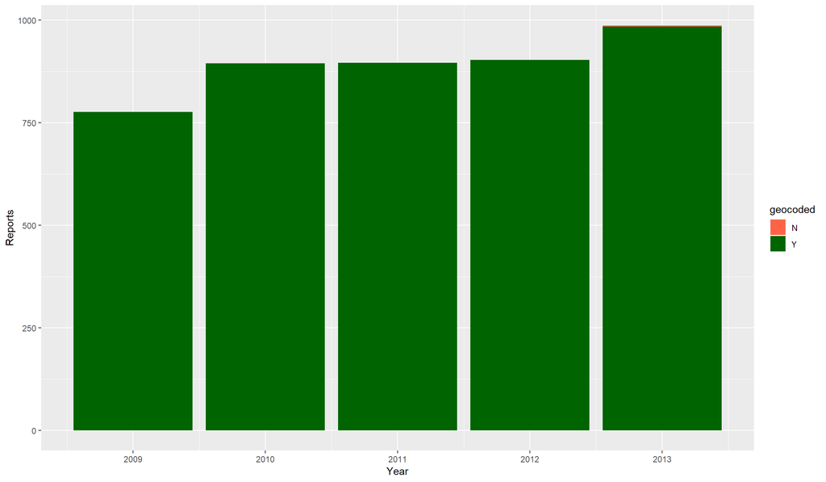

```r
METhistSummary <- METROHistoric %>%
  select(MONTH, YEAR, CRASHES, geocoded) %>%
  group_by(YEAR, geocoded) %>%
  summarize(crashes = sum(CRASHES)) %>%
  mutate(freq = crashes/lead(crashes) * 100)

METhistSummary  %>%
  ggplot(aes(x = YEAR, y = crashes, fill = geocoded)) +
  geom_bar(stat = "identity") +
  xlab("Year") +
  ylab("Reports") +
  scale_fill_manual(values = c("tomato", "darkgreen"))
```

```r
kable(METhistSummary)
```

| YEAR | geocoded | crashes | freq |
| --- | --- | --- | --- |
| 2009 | Y | 776 | NA |
| 2010 | N | 1 | 0.1118568 |
| 2010 | Y | 894 | NA |
| 2011 | Y | 896 | NA |
| 2012 | Y | 903 | NA |
| 2013 | N | 3 | 0.3048780 |
| 2013 | Y | 984 | NA |

## Seasonal reporting

### CRD

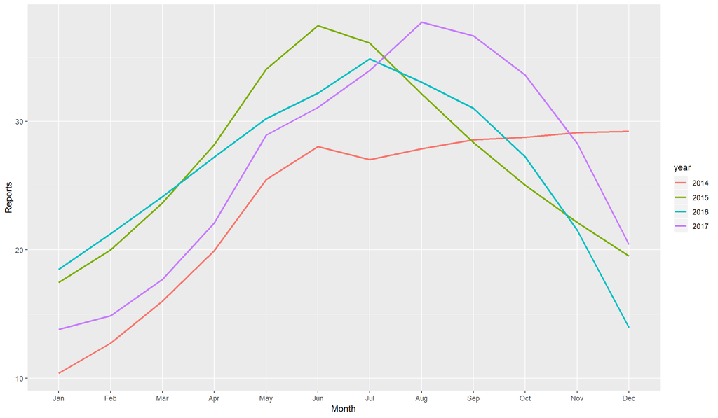

```r
f <- CRD %>%
  mutate(month_short = substr(Month, 1, 3))

f$month_short <- factor(f$month_short, levels = c("Jan", "Feb", "Mar", "Apr", "May", "Jun", "Jul", "Aug", "Sep", "Oct", "Nov", "Dec"))

f$Year <- factor(f$Year)

table <- f %>%
  select(month_short, Year, CRASHES) %>%
  rename(month = month_short,
         year = Year) %>%
  group_by(month, year) %>%
  summarize(crashes = sum(CRASHES)) %>%
  ungroup()

table %>%
  group_by(month, year) %>%
  ggplot(aes(x = month, y = crashes, group = year)) +
  geom_smooth(aes(color = year),  size = 1, se = F, method = 'loess', formula = 'y ~ x') +
  xlab("Month") +
  ylab("Reports")
```

### Kelowna

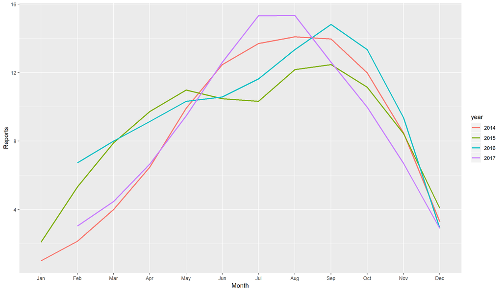

```r
f <- KEL %>%
  mutate(month_short = substr(Month, 1, 3))

f$month_short <- factor(f$month_short, levels = c("Jan", "Feb", "Mar", "Apr", "May", "Jun", "Jul", "Aug", "Sep", "Oct", "Nov", "Dec"))

f$Year <- factor(f$Year)

table <- f %>%
  select(month_short, Year, CRASHES) %>%
  rename(month = month_short,
         year = Year) %>%
  group_by(month, year) %>%
  summarize(crashes = sum(CRASHES)) %>%
  ungroup()

table %>%
  group_by(month, year) %>%
  ggplot(aes(x = month, y = crashes, group = year)) +
  geom_smooth(aes(color = year),  size = 1, se = F, method = 'loess', formula = 'y ~ x') +
  xlab("Month") +
  ylab("Reports")
```

### Metro Vancouver

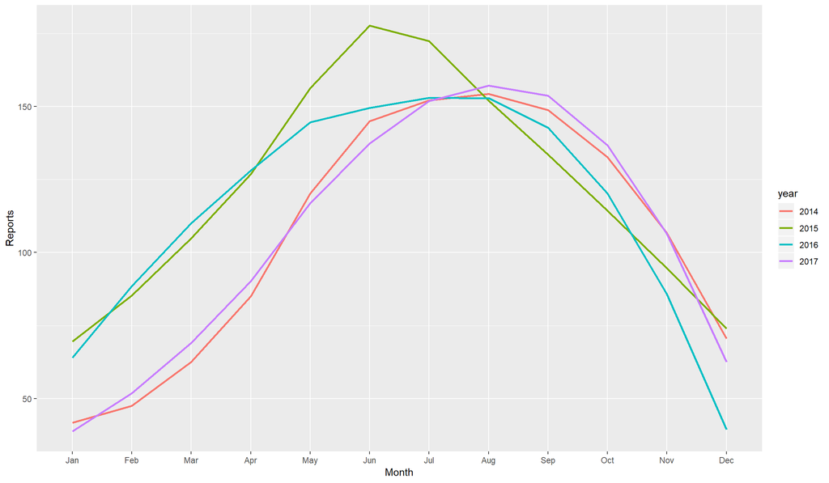

```r
f <- METRO %>%
  mutate(month_short = substr(Month, 1, 3))

f$month_short <- factor(f$month_short, levels = c("Jan", "Feb", "Mar", "Apr", "May", "Jun", "Jul", "Aug", "Sep", "Oct", "Nov", "Dec"))

f$Year <- factor(f$Year)

table <- f %>%
  select(month_short, Year, CRASHES) %>%
  rename(month = month_short,
         year = Year) %>%
  group_by(month, year) %>%
  summarize(crashes = sum(CRASHES)) %>%
  ungroup()

table %>%
  group_by(month, year) %>%
  ggplot(aes(x = month, y = crashes, group = year)) +
  geom_smooth(aes(color = year),  size = 1, se = F, method = 'loess', formula = 'y ~ x') +
  xlab("Month") +
  ylab("Reports")
```

## Proportion geocoded to intersections

### CRD

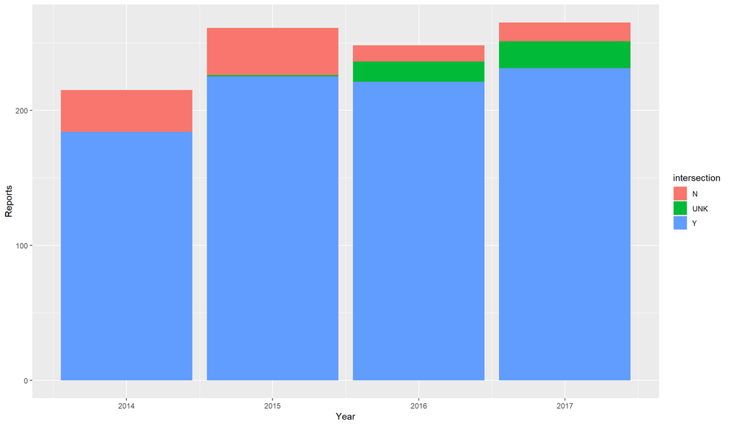

```r
i <- CRD %>%
  rename(loc = `Road Location`) %>%
  mutate(geocoded = if_else(is.na(latitude), "N", "Y")) %>%
  mutate(intersection = if_else(grepl("&", loc), "Y", "N")) %>%
  filter(geocoded == "Y")


i$intersection <- if_else(i$loc == "UNKNOWN", "UNK", i$intersection)

i$intersection <- factor(i$intersection)

i %>%
  group_by(Year, intersection) %>%
  summarize(crashes = sum(CRASHES)) %>%
  ggplot(aes(x = Year, y = crashes, fill = intersection)) +
  geom_bar(stat = "identity") +
  xlab("Year") +
  ylab("Reports")
```

```r
table <- i %>%
  group_by(Year, intersection) %>%
  summarize(crashes = sum(CRASHES)) %>%
  mutate(freq = crashes/sum(crashes) * 100)

kable(table)
```

| Year | intersection | crashes | freq |
| --- | --- | --- | --- |
| 2014 | N | 31 | 14.4186047 |
| 2014 | Y | 184 | 85.5813953 |
| 2015 | N | 35 | 13.4099617 |
| 2015 | UNK | 1 | 0.3831418 |
| 2015 | Y | 225 | 86.2068966 |
| 2016 | N | 12 | 4.8387097 |
| 2016 | UNK | 15 | 6.0483871 |
| 2016 | Y | 221 | 89.1129032 |
| 2017 | N | 14 | 5.2830189 |
| 2017 | UNK | 20 | 7.5471698 |
| 2017 | Y | 231 | 87.1698113 |

### Historic CRD

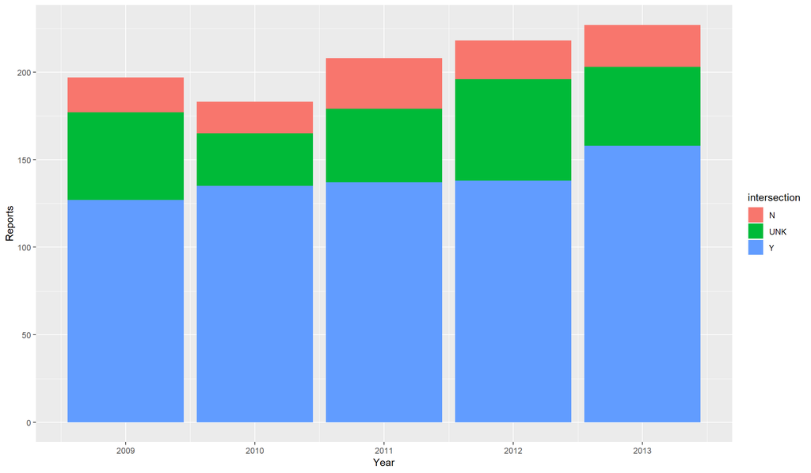

```r
i <- CRDHistoric %>%
  mutate(intersection = if_else(grepl("&", ROAD_LOCATION), "Y", "N")) %>%
  filter(geocoded == "Y")

i$intersection <- if_else(is.na(i$ROAD_LOCATION), "UNK", i$intersection)

i$intersection <- factor(i$intersection)

i %>%
  group_by(YEAR, intersection) %>%
  summarize(crashes = sum(CRASHES)) %>%
  ggplot(aes(x = YEAR, y = crashes, fill = intersection)) +
  geom_bar(stat = "identity") +
  xlab("Year") +
  ylab("Reports")
```

```r
table <- i %>%
  filter(geocoded == "Y") %>%
  group_by(YEAR, intersection) %>%
  summarize(crashes = sum(CRASHES)) %>%
  mutate(freq = crashes/sum(crashes) * 100)

kable(table)
```

| YEAR | intersection | crashes | freq |
| --- | --- | --- | --- |
| 2009 | N | 20 | 10.152284 |
| 2009 | UNK | 50 | 25.380711 |
| 2009 | Y | 127 | 64.467005 |
| 2010 | N | 18 | 9.836066 |
| 2010 | UNK | 30 | 16.393443 |
| 2010 | Y | 135 | 73.770492 |
| 2011 | N | 29 | 13.942308 |
| 2011 | UNK | 42 | 20.192308 |
| 2011 | Y | 137 | 65.865385 |
| 2012 | N | 22 | 10.091743 |
| 2012 | UNK | 58 | 26.605505 |
| 2012 | Y | 138 | 63.302752 |
| 2013 | N | 24 | 10.572687 |
| 2013 | UNK | 45 | 19.823788 |
| 2013 | Y | 158 | 69.603524 |

### Kelowna

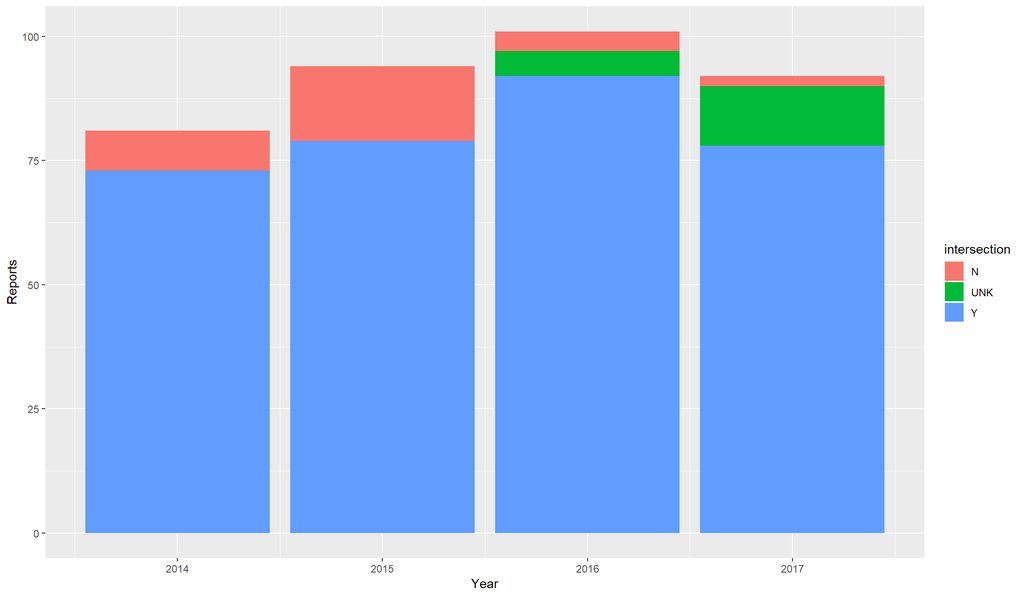

```r
i <- KEL %>%
  rename(loc = `Road Location`) %>%
  mutate(geocoded = if_else(is.na(latitude), "N", "Y")) %>%
  mutate(intersection = if_else(grepl("&", loc), "Y", "N")) %>%
  filter(geocoded == "Y")


i$intersection <- if_else(i$loc == "UNKNOWN", "UNK", i$intersection)

i$intersection <- factor(i$intersection)

i %>%
  group_by(Year, intersection) %>%
  summarize(crashes = sum(CRASHES)) %>%
  ggplot(aes(x = Year, y = crashes, fill = intersection)) +
  geom_bar(stat = "identity") +
  xlab("Year") +
  ylab("Reports")
```

```r
table <- i %>%
  group_by(Year, intersection) %>%
  summarize(crashes = sum(CRASHES)) %>%
  mutate(freq = crashes/sum(crashes) * 100)

kable(table)
```

| Year | intersection | crashes | freq |
| --- | --- | --- | --- |
| 2014 | N | 8 | 9.876543 |
| 2014 | Y | 73 | 90.123457 |
| 2015 | N | 15 | 15.957447 |
| 2015 | Y | 79 | 84.042553 |
| 2016 | N | 4 | 3.960396 |
| 2016 | UNK | 5 | 4.950495 |
| 2016 | Y | 92 | 91.089109 |
| 2017 | N | 2 | 2.173913 |
| 2017 | UNK | 12 | 13.043478 |
| 2017 | Y | 78 | 84.782609 |

### Metro Vancouver

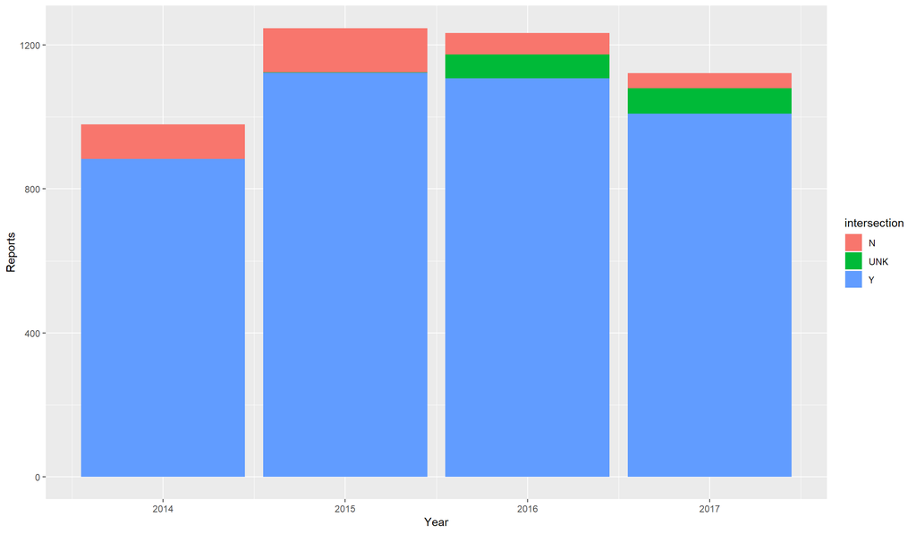

```r
i <- METRO %>%
  rename(loc = `Road Location`) %>%
  mutate(geocoded = if_else(is.na(latitude), "N", "Y")) %>%
  mutate(intersection = if_else(grepl("&", loc), "Y", "N")) %>%
  filter(geocoded == "Y")


i$intersection <- if_else(i$loc == "UNKNOWN", "UNK", i$intersection)

i$intersection <- factor(i$intersection)

i %>%
  group_by(Year, intersection) %>%
  summarize(crashes = sum(CRASHES)) %>%
  ggplot(aes(x = Year, y = crashes, fill = intersection)) +
  geom_bar(stat = "identity") +
  xlab("Year") +
  ylab("Reports")
```

```r
table <- i %>%
  group_by(Year, intersection) %>%
  summarize(crashes = sum(CRASHES)) %>%
  mutate(freq = crashes/sum(crashes) * 100)

kable(table)
```

| Year | intersection | crashes | freq |
| --- | --- | --- | --- |
| 2014 | N | 96 | 9.8059244 |
| 2014 | Y | 883 | 90.1940756 |
| 2015 | N | 123 | 9.8636728 |
| 2015 | UNK | 1 | 0.0801925 |
| 2015 | Y | 1123 | 90.0561347 |
| 2016 | N | 59 | 4.7850770 |
| 2016 | UNK | 67 | 5.4339011 |
| 2016 | Y | 1107 | 89.7810219 |
| 2017 | N | 42 | 3.7433155 |
| 2017 | UNK | 71 | 6.3279857 |
| 2017 | Y | 1009 | 89.9286988 |

### Historic Metro Vancouver

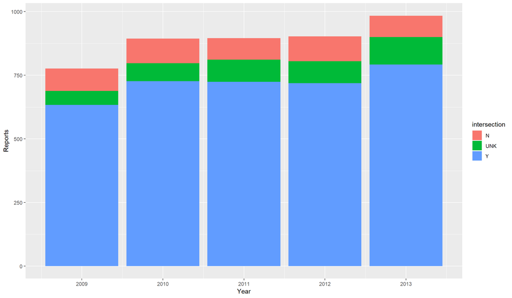

```r
i <- METROHistoric %>%
  mutate(intersection = if_else(grepl("&", ROAD_LOCATION), "Y", "N")) %>%
  filter(geocoded == "Y")

i$intersection <- if_else(is.na(i$ROAD_LOCATION), "UNK", i$intersection)

i$intersection <- factor(i$intersection)

i %>%
  group_by(YEAR, intersection) %>%
  summarize(crashes = sum(CRASHES)) %>%
  ggplot(aes(x = YEAR, y = crashes, fill = intersection)) +
  geom_bar(stat = "identity") +
  xlab("Year") +
  ylab("Reports")
```

```r
table <- i %>%
  filter(geocoded == "Y") %>%
  group_by(YEAR, intersection) %>%
  summarize(crashes = sum(CRASHES)) %>%
  mutate(freq = crashes/sum(crashes) * 100)

kable(table)
```

| YEAR | intersection | crashes | freq |
| --- | --- | --- | --- |
| 2009 | N | 88 | 11.340206 |
| 2009 | UNK | 55 | 7.087629 |
| 2009 | Y | 633 | 81.572165 |
| 2010 | N | 97 | 10.850112 |
| 2010 | UNK | 70 | 7.829978 |
| 2010 | Y | 727 | 81.319911 |
| 2011 | N | 85 | 9.486607 |
| 2011 | UNK | 87 | 9.709821 |
| 2011 | Y | 724 | 80.803571 |
| 2012 | N | 98 | 10.852713 |
| 2012 | UNK | 86 | 9.523810 |
| 2012 | Y | 719 | 79.623477 |
| 2013 | N | 84 | 8.536585 |
| 2013 | UNK | 108 | 10.975610 |
| 2013 | Y | 792 | 80.487805 |

## Interactive maps of ICBC crashes (larger circles indicate more than one incident; click individual non-blue points for road location)

### CRD

```r
#set map parameters
map <- leaflet() %>% setView(lng = -123.367267, lat = 48.434293, zoom = 12)

#map points for each year, for all years, and create a toggle for each layer
map %>% addTiles(group = "OSM") %>%

  addCircleMarkers(lng = Y2014$longitude, lat = Y2014$latitude, #adds circle markers using lat/long from ICBC file
                   popup = as.character(Y2014$rd), #adds a popup
                   radius = if_else(Y2014$crashes == 1, 5, 8), #set circle size
                   stroke = F, #circle outline
                   fillColor = "brown", #circle color
                   fill = T, #circle fill
                   fillOpacity = 100, #circle opacity
                   group = "2014") %>%  #create a "group" for layer toggles
  #same process, 2015
   addCircleMarkers(lng = Y2015$longitude, lat = Y2015$latitude,
                   popup = as.character(Y2015$rd),
                   radius = if_else(Y2015$crashes == 1, 5,8),
                   stroke = F,
                   fillColor = "yellow",
                   fill = T,
                   fillOpacity = 100,
                   group = "2015") %>%
  #same process, 2016
  addCircleMarkers(lng = Y2016$longitude, lat = Y2016$latitude,
                   popup = as.character(Y2016$rd),
                   radius = if_else(Y2016$crashes == 1, 5, 8),
                   stroke = F,
                   fillColor = "orange",
                   fill = T,
                   fillOpacity = 100,
                   group = "2016") %>%
  #same process, 2017
  addCircleMarkers(lng = Y2017$longitude, lat = Y2017$latitude,
                   popup = as.character(Y2017$rd),
                   radius = if_else(Y2017$crashes == 1, 5, 8),
                   stroke = F,
                   fillColor = "red",
                   fill = T,
                   fillOpacity = 100,
                   group = "2017") %>%
  #map all years as a single group
  addCircleMarkers(lng = CRDgeocoded$longitude, lat = CRDgeocoded$latitude,
                   popup = (CRDgeocoded$year),
                   radius = if_else(CRDgeocoded$crashes == 1, 5, 8),
                   stroke = F,
                   fillColor = "blue",
                   fill = T,
                   fillOpacity = 100,
                   group = "AllYears",
                   clusterOptions = markerClusterOptions()) %>%
  #map historical data (2013)

  addLayersControl(
  baseGroups = ("OSM"),
  overlayGroups = c("2014-2017" ,"2014", "2015", "2016", "2017"),
  options = layersControlOptions(collapsed = FALSE))
```

[interactive chart not shown]

### Kelowna

```r
  kmap <- leaflet(width = "100%") %>% setView(lng = -119.4, lat = 49.810654, zoom = 12)

  #map points for each year, for all years, and create a toggle for each layer
  kmap %>% addTiles(group = "OSM") %>%

    addCircleMarkers(lng = K2014$longitude, lat = K2014$latitude, #adds circle markers using lat/long from ICBC file
                     popup = as.character(K2014$rd), #adds a popup
                     radius = if_else(K2014$crashes == 1, 5, 8), #set circle size
                     stroke = F, #circle outline
                     fillColor = "brown", #circle color
                     fill = T, #circle fill
                     fillOpacity = 100, #circle opacity
                     group = "2014") %>%  #create a "group" for layer toggles
    #same process, 2015
    addCircleMarkers(lng = K2015$longitude, lat = K2015$latitude,
                     popup = as.character(K2015$rd),
                     radius = if_else(K2015$crashes == 1, 5, 8),
                     stroke = F,
                     fillColor = "yellow",
                     fill = T,
                     fillOpacity = 100,
                     group = "2015") %>%
    #same process, 2016
    addCircleMarkers(lng = K2016$longitude, lat = K2016$latitude,
                     popup = as.character(K2016$rd),
                     radius = if_else(K2016$crashes == 1, 5, 8),
                     stroke = F,
                     fillColor = "orange",
                     fill = T,
                     fillOpacity = 100,
                     group = "2016") %>%
    #same process, 2017
    addCircleMarkers(lng = K2017$longitude, lat = K2017$latitude,
                     popup = as.character(K2017$rd),
                     radius = if_else(K2017$crashes == 1, 5, 8),
                     stroke = F,
                     fillColor = "red",
                     fill = T,
                     fillOpacity = 100,
                     group = "2017") %>%
    #map all years as a single group
    addCircleMarkers(lng = Kgeocoded$longitude, lat = Kgeocoded$latitude,
                     popup = (Kgeocoded$year),
                     radius = if_else(Kgeocoded$crashes == 1, 5,8),
                     stroke = F,
                     fillColor = "blue",
                     fill = T,
                     fillOpacity = 100,
                     group = "2014-2017",
                     clusterOptions = markerClusterOptions()) %>%


    addLayersControl(
      baseGroups = ("OSM"),
      overlayGroups = c("2014-2017" ,"2014", "2015", "2016", "2017"),
      options = layersControlOptions(collapsed = FALSE))
```

[interactive chart not shown]

### Metro Vancouver

```r
mmap <- leaflet(width = "100%") %>% setView(lng = -123.18526, lat = 49.24, zoom = 12)

  #map points for each year, for all years, and create a toggle for each layer
  mmap %>% addTiles(group = "OSM") %>%

    addCircleMarkers(lng = M2014$longitude, lat = M2014$latitude, #adds circle markers using lat/long from ICBC file
                     popup = as.character(M2014$rd), #adds a popup
                     radius = if_else(M2014$crashes == 1, 5, 8), #set circle size
                     stroke = F, #circle outline
                     fillColor = "brown", #circle color
                     fill = T, #circle fill
                     fillOpacity = 100, #circle opacity
                     group = "2014") %>%  #create a "group" for layer toggles
    #same process, 2015
    addCircleMarkers(lng = M2015$longitude, lat = M2015$latitude,
                     popup = as.character(M2015$rd),
                     radius = if_else(M2015$crashes == 1, 5, 8),
                     stroke = F,
                     fillColor = "yellow",
                     fill = T,
                     fillOpacity = 100,
                     group = "2015") %>%
    #same process, 2016
    addCircleMarkers(lng = M2016$longitude, lat = M2016$latitude,
                     popup = as.character(M2016$rd),
                     radius = if_else(M2016$crashes == 1, 5, 8),
                     stroke = F,
                     fillColor = "orange",
                     fill = T,
                     fillOpacity = 100,
                     group = "2016") %>%
    #same process, 2017
    addCircleMarkers(lng = M2017$longitude, lat = M2017$latitude,
                     popup = as.character(M2017$rd),
                     radius = if_else(M2017$crashes == 1, 5, 8),
                     stroke = F,
                     fillColor = "red",
                     fill = T,
                     fillOpacity = 100,
                     group = "2017") %>%
    #map all years as a single group
    addCircleMarkers(lng = Mgeocoded$longitude, lat = Mgeocoded$latitude,
                     popup = (Mgeocoded$year),
                     radius = if_else(Mgeocoded$crashes == 1, 5,8),
                     stroke = F,
                     fillColor = "blue",
                     fill = T,
                     fillOpacity = 100,
                     group = "2014-2017",
                     clusterOptions = markerClusterOptions()) %>%


    addLayersControl(
      baseGroups = ("OSM"),
      overlayGroups = c("2014-2017" ,"2014", "2015", "2016", "2017"),
      options = layersControlOptions(collapsed = FALSE))
```

[interactive chart not shown]